# Impacto del transporte entre la residencia del alumno y la universidad en su tiempo efectivo de trabajo y rendimiento académico

## Título corto: CommUtec

## P5 Entrega Final

### **Sección:** 1.01

### **Profesor:** José Miguel Renom

| **Alumno** | **Código** | **Líder** |
| --- | --- | --- |
| Kevin Aubert | 201910019 |  |
| Andrea Chu | 201910124 |  |
| Juan Diego Chu | 201920069 |  |
| Oscar Gómez | 201910179 |  |
| Joaquín Ramírez | 201910277 | X |

### Introducción

El transporte urbano de Lima está en un estado deplorable debido a años de corrupción y manejo indebido de los recursos públicos. Uno de los principales problemas en una sociedad urbanizada es la movilización eficiente de los ciudadanos en el limitado espacio disponible. Según un estudio realizado por la empresa holandesa TomTom (2018), Lima es la tercera ciudad con más tráfico en el mundo. Esto significa que muchos limeños debemos invertir una gran cantidad de horas en transportarnos, debido a que el tráfico nos impide llegar a lugares más rápidamente.

Como estudiantes, consideramos que este tema es importante para nosotros y nuestros compañeros porque todos vivimos en Lima y debemos transportarnos a la universidad frecuentemente. Muchas de estas veces, nos topamos con el tráfico y largas horas de movilidad. Todo esto resulta en una carga físico-emocional que repercute en la vida diaria estudiantil, el cual no nos permite rendir a nuestro máximo potencial.

### Objetivo

El objetivo de esta investigación es analizar e informar acerca del impacto que tiene el transporte desde la residencia de un alumno hasta la universidad en su tiempo efectivo de trabajo, rendimiento académico y estilo de vida.

### Población objetivo

Estudiantes de UTEC

### Unidad muestral

Cualquier estudiante de UTEC cursando ciclo II en adelante

### Tipo de muestreo

Muestreo por conveniencia: fácil acceso a nuestra unidad muestral

### Obtención de datos

Al ser parte de la comunidad estudiantil de la misma universidad, tenemos acceso a los medios de comunicación pertinentes para realizar encuestas en línea. Es así que se elaboró una encuesta en GoogleForms, y se distribuyó la misma vía el grupo de Facebook de los alumnos. Asimismo, solicitamos ayuda del área de Bienestar Estudiantil que nos apoyó con la distribución de la encuesta. Nota: para poder responder las preguntas que toman los factores de opinión y el plano emocional, se utilizó escalas psicométricas, como la escala de Likert.

### Preguntas planteadas

| N° | Pregunta | Tipo de pregunta |
| --- | --- | --- |
| 1 | ¿Cuánto tiempo les demora a los estudiantes de UTEC llegar a la universidad desde su lugar de residencia? | Descriptiva |
| 2 | ¿Cómo califican los estudiantes la experiencia de transporte? | Descriptiva |
| 3 | ¿Cuál es el medio de transporte más utilizado? | Descriptiva |
| 4 | ¿Qué tan estresados se sentían los alumnos de UTEC el ciclo 2019-2? | Descriptiva |
| 5 | ¿Cuántas horas de sueño tienen los alumnos de UTEC? | Descriptiva |
| 6 | ¿Existe una relación entre el número de horas que duermen los estudiantes y el nivel de estrés que presentan? | Exploratoria |
| 7 | ¿Existe alguna relación entre el tiempo que pasan en el transporte y la cantidad de cursos desaprobados del estudiante? | Exploratoria |
| 8 | ¿Los estudiantes que viajan más a la semana dormirán una menor cantidad de horas? | Inferencial |
| 9 | ¿Los estudiantes que viajan menos horas a la semana en el transporte tendrán una mejor calificación de este? | Inferencial |
| 10 | ¿Es posible predecir las horas de sueño que tendrán los alumnos conociendo su nivel de estrés y la calificación de su experiencia en el transporte? | Predictiva |
| 11 | ¿Es posible predecir la calificación sobre el transporte conociendo únicamente el número de horas que se transportan a la semana? | Predictiva |
| 12 | ¿Qué factores y condiciones en los que se desarrolla el alumno determinan la calificación que tendrás sobre el transporte? | Causal |
| 13 | ¿De qué manera algunos factores afectan la calificación de los alumnos sobre el transporte? | Mecanística |

### Variables del Estudio

| Variable | Relación con pregunta | Tipo de variable |
| --- | --- | --- |
| Calificación de la Experiencia de transporte | 2,9,10,11,12,13 | Categórica ordinal |
| Tiempo de transporte diario | 1,7,12,13 | Numérica continua |
| Cantidad de cursos desaprobados | 7 | Numérica discreta |
| Medios de transporte | 3,12,13 | Categórica nominal |
| Cantidad de días con clases | 8,9,11,12,13 | Numérica discreta |
| Cantidad de horas semanales de clases | 12,13 | Numérica continua |
| Horas de sueño diarias | 5,6,8,10 | Numérica continua |
| Distrito de Residencia | 12,13 | Categórica nominal |
| Tiempo de transporte semanal | 8,9,11,12,13 | Numérica continua |
| Nivel de estrés (referencial basado en escala) | 4,6,10 | Categórica ordinal |

**Para medir el nivel de estrés utilizamos el siguiente Cuestionario de Problemas Psicosomáticos(CPP) del Instituto Mexicano del Seguro Social:**

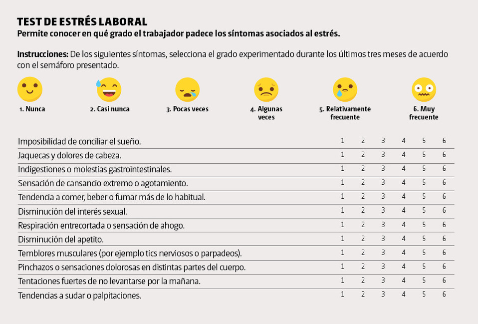

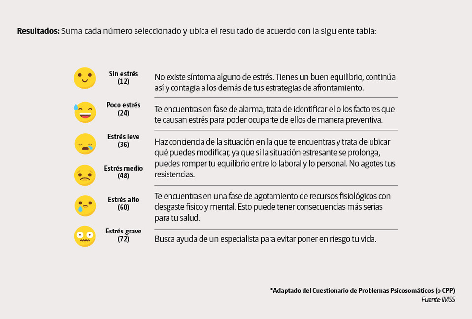

```r
#install.packages("RColorBrewer")
```

### Base de Datos

```r
library(RColorBrewer)
library(readr)
library(dplyr)
DF<-read_csv("Base_DatosFINAL.csv")
```

### ¿Cuánto tiempo les demora a los estudiantes de UTEC llegar a la universidad desde su lugar de residencia?

**ANÁLISIS:** A partir de la gráfica podemos observar que el promedio de tiempo de transporte de los estudiantes es de 51.81 minutos y que la mediana es de 45 minutos; lo que significa que más de la mitad de los alumnos se demora menos de 45 minutos. Asimismo, el tiempo máximo es de 150 minutos y el mínimo de 2 minutos, lo cual podría ser causado por la distancia a su residencia o el método de transporte utilizado. Finalmente, mediante la relación entre media y mediana obtenemos que la distribución de datos es sesgada hacia la derecha.

```r
summary(DF$Tiempo_Transporte/2)
```

```
##    Min. 1st Qu.  Median    Mean 3rd Qu.    Max.
##    2.00   25.00   45.00   51.81   75.00  150.00
```

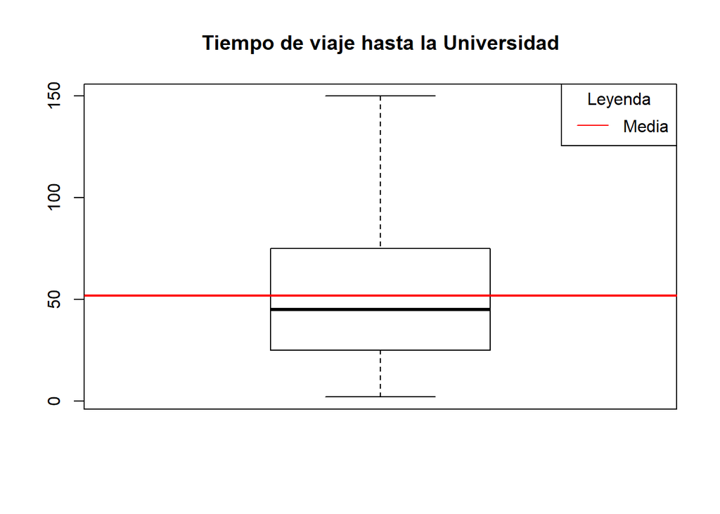

```r
boxplot(DF$Tiempo_Transporte/2)
abline(mean(DF$Tiempo_Transporte/2),0,col="red",title("Tiempo de viaje hasta la Universidad"), lwd=2)
legend("topright",
       c("Media"),
       lty=1,
       col=c("red"),
       bty = "o", title="Leyenda",bg="transparent")
```

### ¿Cómo califican los estudiantes la experiencia de transporte?

**ANÁLISIS:** La gráfica presenta la distribución de la frecuencia referente a la calificación de la experiencia de transporte de los estudiantes de la UTEC. Se puede observar que la mayoría de estudiantes califica el transporte con un valor relativamente alto con una mediana de 7 y una media de 6.572. Basándonos en esto se puede concluir que la mayoría de los estudiantes califica su experiencia de transporte como positiva.

```r
summary(DF$Calificacion)
```

```
##    Min. 1st Qu.  Median    Mean 3rd Qu.    Max.
##   1.000   5.000   7.000   6.572   8.000  10.000
```

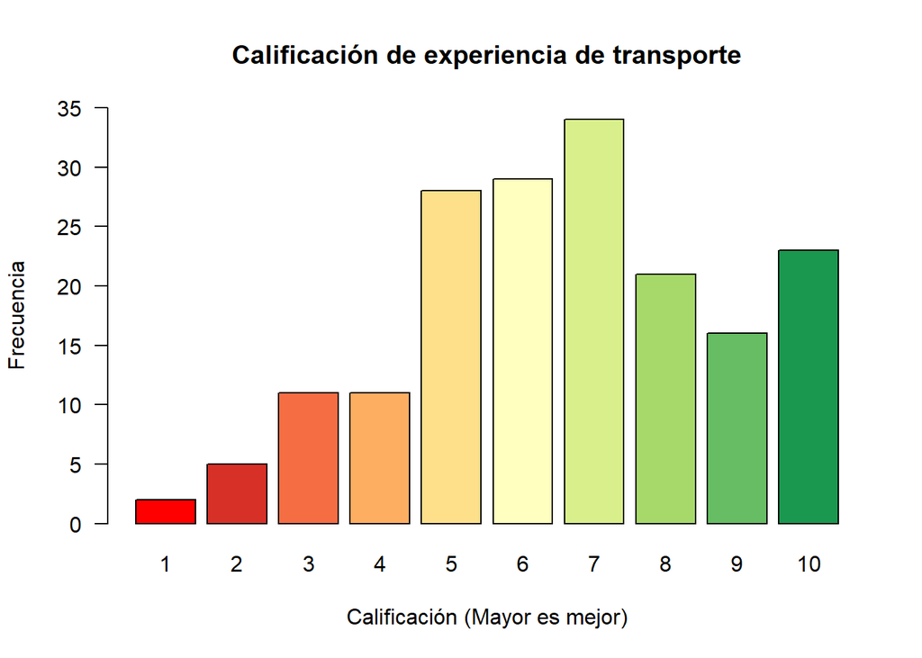

```r
col <- brewer.pal(9, "RdYlGn")
barplot(table(DF$Calificacion), xlab="Calificación (Mayor es mejor)", ylab="Frecuencia", las=1,cex.names=1,ylim=c(0,35), col=c("red",col), main = "Calificación de experiencia de transporte")
```

### ¿Cuál es el medio de transporte más utilizado?

```r
medios <- read_csv("TransporteF.csv") #medios es igual a la suma de M1, M2, M3 Y M4 en DF
```

**Porcentajes de los medios de transporte (%):**

```r
round(table(medios$Actividad)/length(medios$Actividad)*100,2)
```

```
##
##                  A pie              Bicicleta                  Carro
##                    6.0                    9.2                   20.0
## Metropolitano/corredor            Micro/combi        Otro transporte
##                   18.4                   28.0                    3.6
##                   Taxi
##                   14.8
```

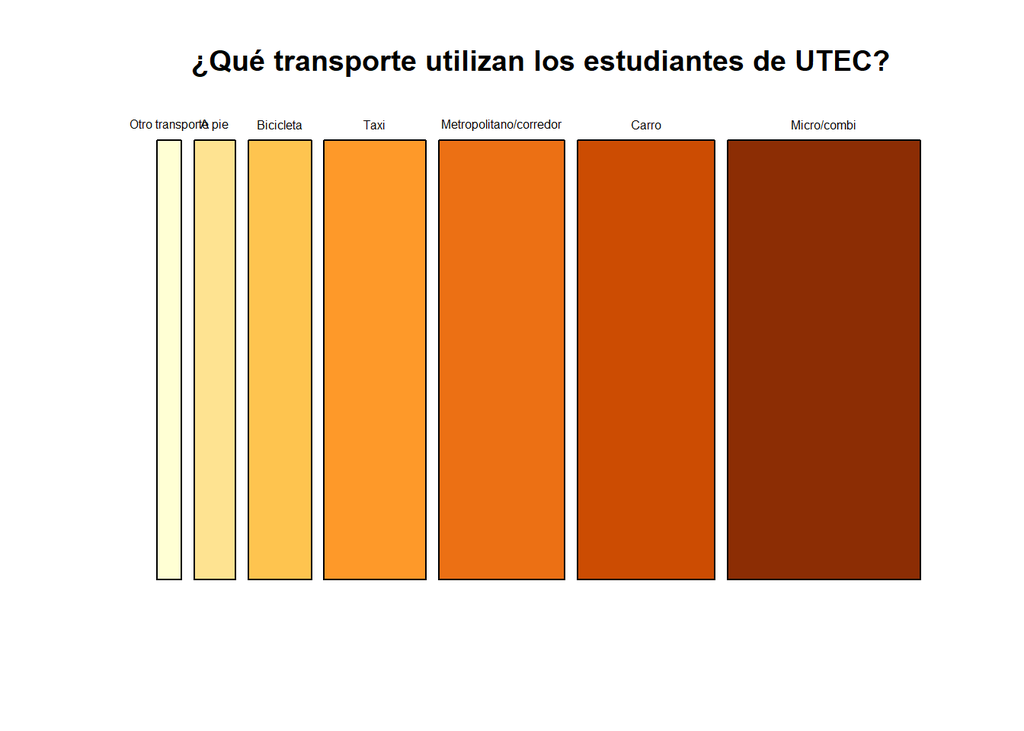

```r
col <- brewer.pal(7, "YlOrBr")
mosaicplot(sort(table(medios$Actividad)),
 main="¿Qué transporte utilizan los estudiantes de UTEC?",
 col=col, las=1,cex.axis = 0.5)
```

### ¿Qué tan estresados se sentían los alumnos de UTEC el ciclo 2019-2?

**ANÁLISIS:** En el gráfico se puede apreciar que aproximadamente la moda entre los alumnos de UTEC es un nivel de estrés leve, mientras que la mediana es un nivel de estrés medio. Asimismo se sabe que la mayoría de alumnos tienen *Estrés leve (25 a 36) o Estrés medio (37 a 48)* con un porcentaje en los alumnos de 30% y 29.44% respectivamente. Finalmente se observa que la cantidad de alumnos con *Estrés grave* es muy baja, ocurriendo solamente en el 8.33% de los alumnos.

```r
rangos_estres <- round(table((cut(DF$Estres,breaks=seq(12,83,by=12), include.lowest = TRUE)))/nrow(DF),4)*100
```

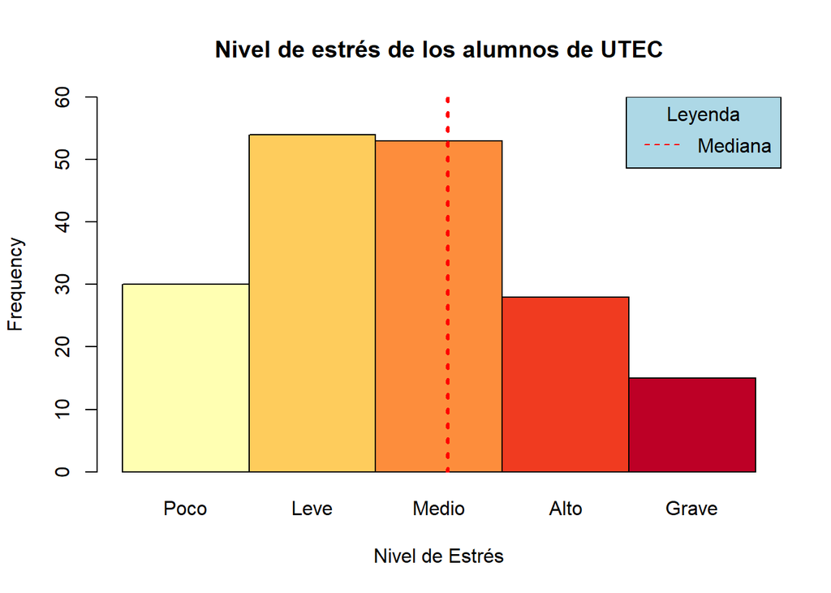

```r
coul <- brewer.pal(5, "YlOrRd")
barplot(table((cut(DF$Estres,breaks=seq(12,83,by=12), include.lowest = TRUE))), ylim = c(0,60),col =coul, space = 0,names.arg = c("Poco","Leve","Medio","Alto","Grave"),xlab="Nivel de Estrés", ylab="Frequency",main="Nivel de estrés de los alumnos de UTEC")
legend("topright",
       c("Mediana"),
       lty=c(2, 2),
       col=c("red"),
       bty = "o", title="Leyenda",bg="lightblue")
abline(v=5*median(DF$Estres)/72,col="red", lwd=3,lty=3)
```

**Porcentaje de Niveles de Estrés en Alumnos (%):**

**Poco Estrés:**

```r
rangos_estres[1]
```

```
## [12,24]
##   16.67
```

**Estrés leve:**

```r
rangos_estres[2]
```

```
## (24,36]
##      30
```

**Estrés medio:**

```r
rangos_estres[3]
```

```
## (36,48]
##   29.44
```

**Estrés alto:**

```r
rangos_estres[4]
```

```
## (48,60]
##   15.56
```

**Estrés grave:**

```r
rangos_estres[5]
```

```
## (60,72]
##    8.33
```

### ¿Cuántas horas de sueño tienen los alumnos de UTEC?

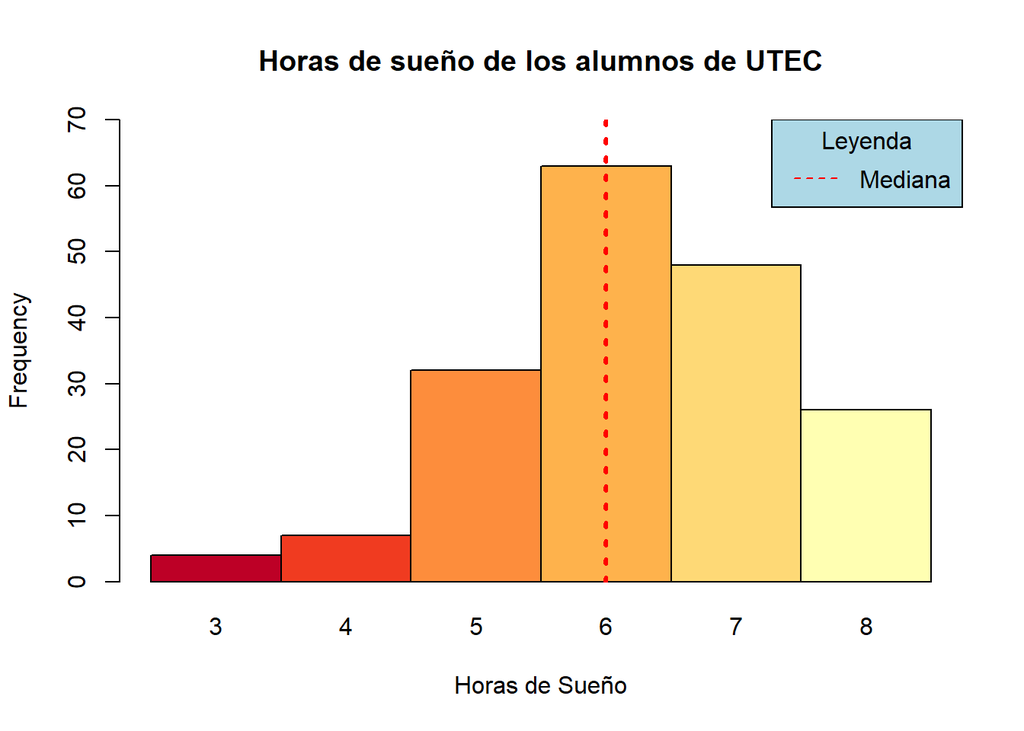

```r
coul <- brewer.pal(6, "YlOrRd")
coulf=c()
for (i in 1:6){
  coulf=c(coulf,coul[7-i])
}
barplot(table((cut(DF$Tiempo_Dormir,breaks=seq(2,8,by=1)))), ylim = c(0,70),col =coulf, space = 0,names.arg = c(3:8),xlab="Horas de Sueño", ylab="Frequency",main="Horas de sueño de los alumnos de UTEC")
legend("topright",
       c("Mediana"),
       lty=c(2, 2),
       col=c("red"),
       bty = "o", title="Leyenda",bg="lightblue")
abline(v=median(DF$Tiempo_Dormir)/2 + 0.5,col="red", lwd=3,lty=3)
```

### Parámetros del estudio

**Tamaño de Muestra:** 180 encuestados

**Nivel de Confianza:** 95% Elegimos un nivel de confianza del 95% puesto que esto significa que si hubiésemos hecho 20 muestreos y creado 20 intervalos de confianza; se esperaría que 19 de ellos contengan la media de la población. Lo cual representa un porcentaje bastante aceptable para una investigación. Además, 95% es el valor que usualmente se utiliza en este tipo de trabajos.

**Nivel de Significancia:** 0.05 El nivel de significancia para este caso estará dado por $\alpha=0.05$, el cuál participa en el cálculo del nivel de confianza según la ecuación $1-\alpha= \text{Nivel de confianza}$.

**Tolerancia:** La tolerancia (epsilon) está dada en la fórmula:
$$\mathbb{P}(\left\vert \overline{X}_n - \mu \right\vert \leq \varepsilon)\geq 1-\alpha$$
De la cual se llega a:

$$\varepsilon=\frac{Z_a\sigma}{\sqrt{n}}$$
$$a=\alpha/2$$
Pero como Z es:

```r
alfa<- 0.05
n=180
z<- qnorm(alfa/2, lower.tail = FALSE)
"Z="
```

```
## [1] "Z="
```

```r
round(z,2)
```

```
## [1] 1.96
```

Finalmente la tolerancia quedaría como:
$$\varepsilon=\frac{Z\sigma}{\sqrt{180}}$$
Donde se utiliza el valor de la desviación estándar de cada variable para $sigma$.

### Intervalos de confianza

La fórmula de los intervalos de confianza es la siguiente:
$$[\overline{X}-\varepsilon, \overline{X}+\varepsilon]$$
Usamos la fórmula para hallar los intervalos de confianza de las principales variables del estudio:

**TIEMPO DE TRANSPORTE DIARIO**

```r
T1<-mean(DF$Tiempo_Transporte)-z*(sd(DF$Tiempo_Transporte)/sqrt(180))
T2<-mean(DF$Tiempo_Transporte)+z*(sd(DF$Tiempo_Transporte)/sqrt(180))
T1
```

```
## [1] 93.50873
```

```r
T2
```

```
## [1] 113.7246
```

**Intervalo de Confianza para la media del Tiempo de Transporte diario=** [93.50873, 113.7246]

**TIEMPO DE TRANSPORTE SEMANAL**

```r
TS1<-mean(DF$Transporte_Semanal)-z*(sd(DF$Transporte_Semanal)/sqrt(180))
TS2<-mean(DF$Transporte_Semanal)+z*(sd(DF$Transporte_Semanal)/sqrt(180))
TS1
```

```
## [1] 470.9614
```

```r
TS2
```

```
## [1] 576.8719
```

**Intervalo de Confianza para la media del Tiempo de Transporte semanal=** [470.9614, 576.8719]

**HORAS DE SUEÑO:**

```r
HS1<-mean(DF$Tiempo_Dormir)-z*(sd(DF$Tiempo_Dormir)/sqrt(180))
HS2<-mean(DF$Tiempo_Dormir)+z*(sd(DF$Tiempo_Dormir)/sqrt(180))
HS1
```

```
## [1] 6.064811
```

```r
HS2
```

```
## [1] 6.401855
```

**Intervalo de Confianza para la media de Horas de Sueño=** [6.064811, 6.401855]

**NÚMERO DE CURSOS REPROBADOS**

```r
NR1<-mean(DF$NroReprobados)-z*(sd(DF$NroReprobados)/sqrt(180))
NR2<-mean(DF$NroReprobados)+z*(sd(DF$NroReprobados)/sqrt(180))
NR1
```

```
## [1] 0.2222592
```

```r
NR2
```

```
## [1] 0.3888519
```

**Intervalo de Confianza para la media de Número de cursos Reprobados=** [0.2222592, 0.3888519]

### ANÁLISIS EXPLORATORIO E INFERENCIAL

### ¿Existe una relación entre el número de horas que duermen los estudiantes y el nivel de estrés que presentan?

**RELEVANCIA PARA EL ESTUDIO:**

La importancia de esta pregunta en el estudio se debe a que el nivel de estrés y las horas de sueño diarias están ligadas con el estilo de vida y con la organización del tiempo de un estudiante de UTEC.

**ANÁLISIS EXPLORATORIO:**

Se puede observar que todos los estudiantes que tienen un nivel de *estrés bajo* duermen 5 horas o más. Además se puede ver una cierta tendencia en la gráfica que apoya nuestra hipótesis nula que los estudiantes que duermen menos sufren de un mayor nivel de estrés.

**HIPÓTESIS:** **H0:** Los estudiantes que tienen un nivel de estrés mayor, duermen menos horas diariamente.

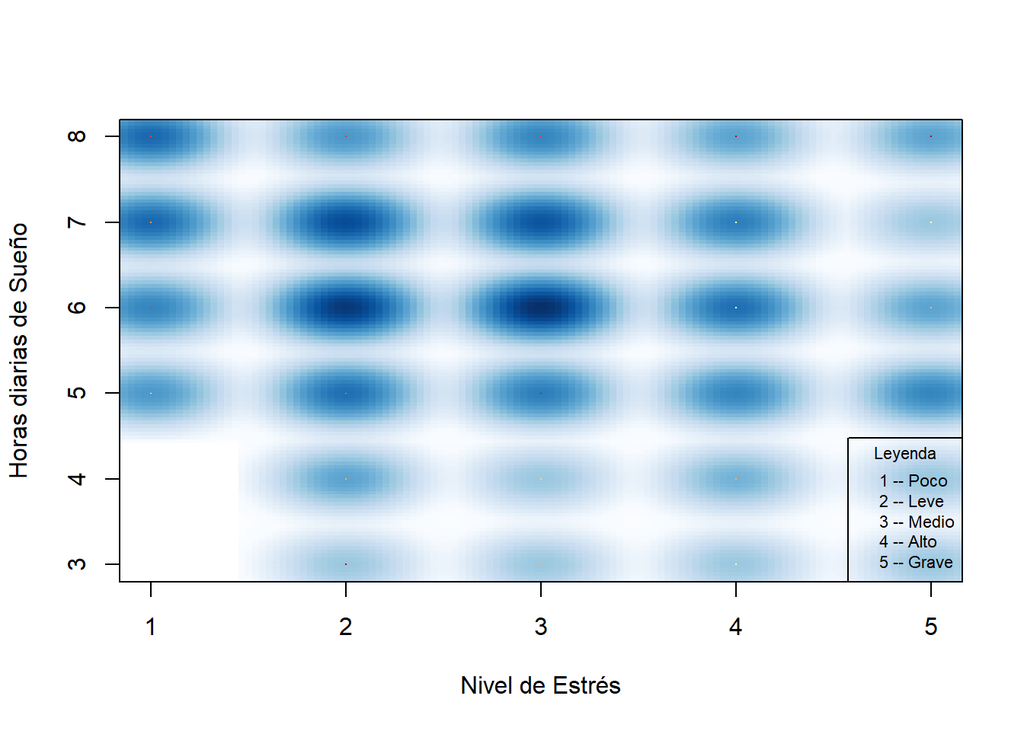

```r
smoothScatter((cut(DF$Estres,breaks=seq(12,83,by=12), include.lowest = TRUE)), DF$Tiempo_Dormir,ylab= "Horas diarias de Sueño",xlab="Nivel de Estrés", col = coul)
legend("bottomright",
       c("1 -- Poco", "2 -- Leve","3 -- Medio","4 -- Alto","5 -- Grave"),
       bty = "o", title="Leyenda",bg="transparent",pt.cex = 1,cex = 0.7)
```

```r
DF%>% filter()%>%group_by(Tiempo_Dormir)%>%summarise(Media_Tiempo=mean(Transporte_Semanal),Mediana_Tiempo=median(Transporte_Semanal))->dormir_transporte
dormir_transporte
```

| Tiempo_Dormir | Media_Tiempo | Mediana_Tiempo |
| --- | --- | --- |
| 3 | 630.0000 | 300 |
| 4 | 564.2857 | 600 |
| 5 | 586.8750 | 600 |
| 6 | 597.8571 | 600 |
| 7 | 483.7500 | 380 |
| 8 | 314.2308 | 300 |

**ANÁLISIS INFERENCIAL:**

Utilizaremos el valor de estrés medio, **48**, para usarlo como punto medio para los estudiantes que tienen un estrés mayo o menor que la mayoría.

```r
Estresmayor<-(DF[which(DF$Estres>48),])
summary(Estresmayor$Tiempo_Dormir)
```

```
##    Min. 1st Qu.  Median    Mean 3rd Qu.    Max.
##   3.000   5.000   6.000   5.907   7.000   8.000
```

Asimismo, consideraremos un tiempo de sueño inferior cuando este se ubique por debajo de la media de **5.907 horas**.

**H0:** Los que tienen un nivel de estrés mayor duermen menos.

**H1:** El tiempo que duerme un alumno no afecta su nivel de estrés.

**Nivel de confianza:** 95%

**alpha**=0.05

```r
t.test(Estresmayor$Tiempo_Dormir,mu=5.907,alternative="greater", conf.level = 0.95)
```

```
##
##  One Sample t-test
##
## data:  Estresmayor$Tiempo_Dormir
## t = -0.00011518, df = 42, p-value = 0.5
## alternative hypothesis: true mean is greater than 5.907
## 95 percent confidence interval:
##  5.56737     Inf
## sample estimates:
## mean of x
##  5.906977
```

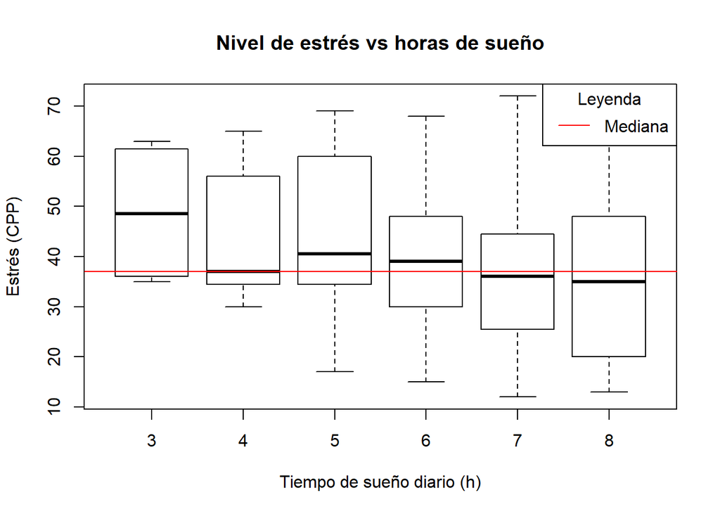

```r
boxplot(DF$Estres~DF$Tiempo_Dormir,main="Nivel de estrés vs horas de sueño", xlab= "Tiempo de sueño diario (h)",ylab="Estrés (CPP)")
abline(h=median(DF$Estres),col="red")
legend("topright", c("Mediana"),lty=c(1), col=c("red"),title="Leyenda",bg="white")
```

**Prueba chi-squared**

H0: Las variables son independientes H1: Las variables son dependientes

```r
chisq.test(table(DF$Estres, DF$Tiempo_Dormir))
```

```
##
##  Pearson's Chi-squared test
##
## data:  table(DF$Estres, DF$Tiempo_Dormir)
## X-squared = 235.96, df = 245, p-value = 0.6492
```

El p-value es mayor a la significancia, entonces no se puede rechazar la hipótesis nula.

### ¿Existe alguna relación entre el tiempo que pasan en el transporte y la cantidad de cursos desaprobados del estudiante?

**RELEVANCIA PARA EL ESTUDIO:**

Esta Pregunta es relevante al estudio ya que nos permite averiguar la relación que tienen los estudiantes que se toman más tiempo en transportarse hacia la universidad y cuantos cursos desaprobados tuvieron. Además de estas dos variables, también nos permitirá relacionar el tiempo de transporte con promedio ponderado ya que un curso reprobado reducirá este.

**ANÁLISIS EXPLORATORIO:**

En el gráfico se puede observar que la mediana para 0 cursos desaprobados es menor a la mediana de 1 curso y 2 cursos desaprobados; por lo que parece que existiría una relación entre estas variables.

**HIPÓTESIS:** **H0:** Los alumnos que pasan un mayor tiempo al transportarse hacia la universidad tendrán un mayor número de cursos desaprobados.

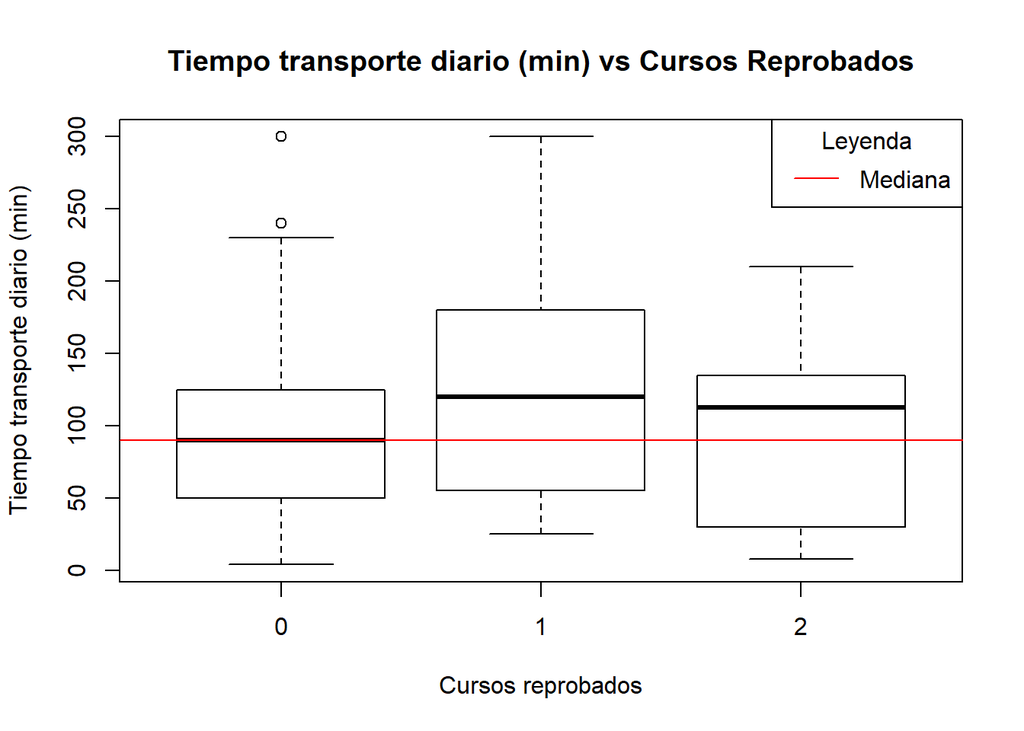

```r
boxplot(DF$Tiempo_Transporte~DF$NroReprobados,main="Tiempo transporte diario (min) vs Cursos Reprobados", xlab= "Cursos reprobados",ylab="Tiempo transporte diario (min)")
abline(h=median(DF$Tiempo_Transporte),col="red")
legend("topright", c("Mediana"),lty=c(1), col=c("red"),title="Leyenda",bg="white")
```

**ANÁLISIS INFERENCIAL:**

**H0:** Los alumnos que pasan un mayor tiempo al transportarse hacia la universidad tendrán un mayor número de cursos desaprobados.

**H1:** Los alumnos que pasan un mayor tiempo al transportarse hacia la universidad tendrán un menor número de cursos desaprobados.

**Nivel de confianza:** 95%

**alpha**=0.05

**Comparando 0 vs 1 desaprobados:** En esta prueba se hará un t.test sobre los alumnos que tienen 0 y 1 cursos desaprobados.

**H0:** los alumnos que tienen un curso desaprobado pasarán más tiempo al transportarse. **H1:** los alumnos que tienen un curso desaprobado pasarán menos tiempo al transportarse.

```r
jalados1<-(DF[which(DF$NroReprobados<=1),])
summary(jalados1$Tiempo_Transporte)
```

```
##    Min. 1st Qu.  Median    Mean 3rd Qu.    Max.
##       4      50      90     104     150     300
```

```r
t.test(jalados1$Tiempo_Transporte,mu=104,alternative = "greater",conf.level = 0.95)
```

```
##
##  One Sample t-test
##
## data:  jalados1$Tiempo_Transporte
## t = -0.007697, df = 169, p-value = 0.5031
## alternative hypothesis: true mean is greater than 104
## 95 percent confidence interval:
##  95.11089      Inf
## sample estimates:
## mean of x
##  103.9588
```

El p-value es mayor a nuestro alpha (0.5031>0.05), entonces no es posible descartar satisfactoriamente la hipótesis nula.

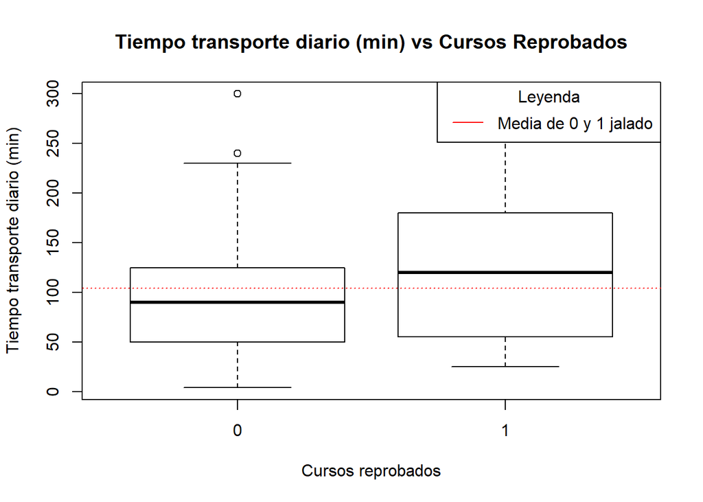

```r
boxplot(jalados1$Tiempo_Transporte~jalados1$NroReprobados,main="Tiempo transporte diario (min) vs Cursos Reprobados", xlab= "Cursos reprobados",ylab="Tiempo transporte diario (min)")
abline(h=c(mean(jalados1$Tiempo_Transporte)),col=c("red"),lty=3)
legend("topright", c("Media de 0 y 1 jalado"),lty=c(1), col=c("red"),title="Leyenda",bg="white")
```

**H0:** los alumnos que tienen dos curso desaprobados pasarán más tiempo al transportarse. **H1:** los alumnos que tienen un curso desaprobado pasarán menos tiempo al transportarse.

```r
jalados2<-(DF[which(DF$NroReprobados!=1),])
summary(jalados2$Tiempo_Transporte)
```

```
##    Min. 1st Qu.  Median    Mean 3rd Qu.    Max.
##     4.0    50.0    90.0    98.7   130.0   300.0
```

```r
t.test(jalados2$Tiempo_Transporte,mu=98.7,alternative = "greater",conf.level = 0.95)
```

```
##
##  One Sample t-test
##
## data:  jalados2$Tiempo_Transporte
## t = -0.0006148, df = 144, p-value = 0.5002
## alternative hypothesis: true mean is greater than 98.7
## 95 percent confidence interval:
##  89.41116      Inf
## sample estimates:
## mean of x
##  98.69655
```

El p-value es mayor a nuestro alpha (0.5002>0.05), entonces no es posible descartar satisfactoriamente la hipótesis nula.

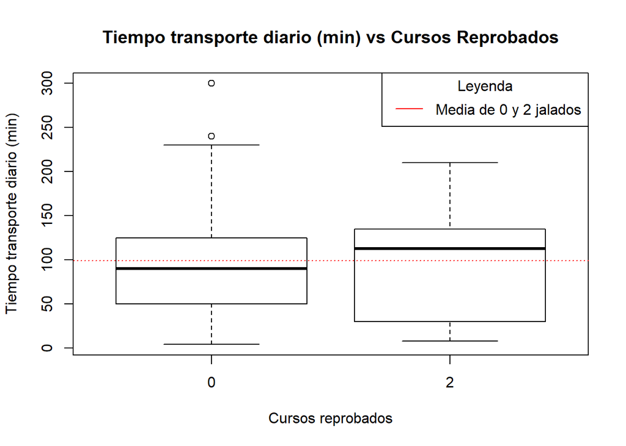

```r
boxplot(jalados2$Tiempo_Transporte~jalados2$NroReprobados,main="Tiempo transporte diario (min) vs Cursos Reprobados", xlab= "Cursos reprobados",ylab="Tiempo transporte diario (min)")
abline(h=c(mean(jalados2$Tiempo_Transporte)),col=c("red"),lty=3)
legend("topright", c("Media de 0 y 2 jalados"),lty=c(1), col=c("red"),title="Leyenda",bg="white")
```

### ¿Existe alguna relación entre las horas que se transportan semanalmente y las horas que duermen los estudiantes?

**RELEVANCIA PARA EL ESTUDIO:**

Esta pregunta es relevante al estudio ya que nos permite relacionar el tiempo de sueño de un estudiante con las horas que este duerme a la semana. Estudios demuestran que la falta de sueño afecta la salud, el rendimiento académico y el nivel de estrés y queríamos ver si había una relación directa entre tiempo de sueño y tiempo de transporte semanal.

**ANÁLISIS EXPLORATORIO:**

Con los datos obtenidos hasta el momento pareciera que hay una tendencia en las gráfica y en la tabla; dado que mientras mientras los alumnos pasan menos horas en el tráfico de la ciudad, más tiempo tendrá para dormir cada día.

**HIPÓTESIS:** **H0:** A menor tiempo de sueño del estudiante, mayor será el tiempo de transporte hacia la universidad. **H1:** A menor tiempo de sueño del estudiante, menor será el tiempo de transporte hacia la universidad.

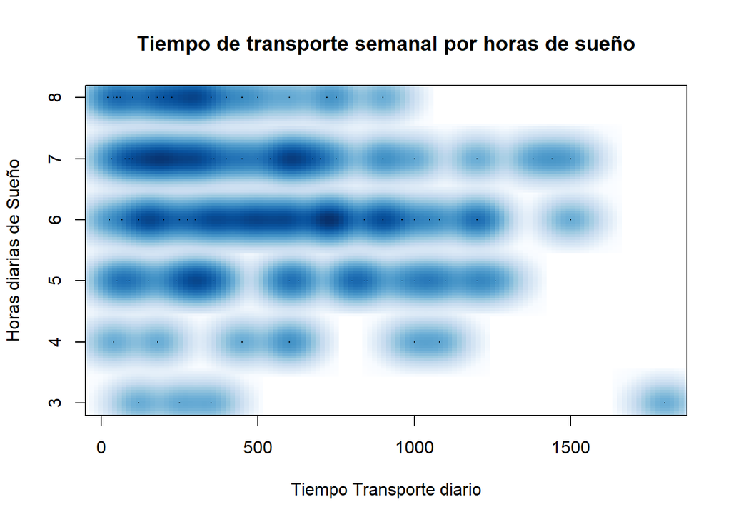

```r
smoothScatter(DF$Transporte_Semanal,DF$Tiempo_Dormir,ylab= "Horas diarias de Sueño",xlab="Tiempo Transporte diario", main="Tiempo de transporte semanal por horas de sueño")
```

```r
DF%>% filter()%>%group_by(Tiempo_Dormir)%>%summarise(Mediana_Tiempo=median(Transporte_Semanal))->Dormir_transporte
Dormir_transporte
```

| Tiempo_Dormir | Mediana_Tiempo |
| --- | --- |
| 3 | 300 |
| 4 | 600 |
| 5 | 600 |
| 6 | 600 |
| 7 | 380 |
| 8 | 300 |

**ANÁLISIS INFERENCIAL:**

```r
dmenos<-(DF[which(DF$Tiempo_Dormir<=5),])
dmas<-(DF[which(DF$Tiempo_Dormir>=6),])
summary(DF$Transporte_Semanal)
```

```
##    Min. 1st Qu.  Median    Mean 3rd Qu.    Max.
##    20.0   240.0   450.0   523.9   750.0  1800.0
```

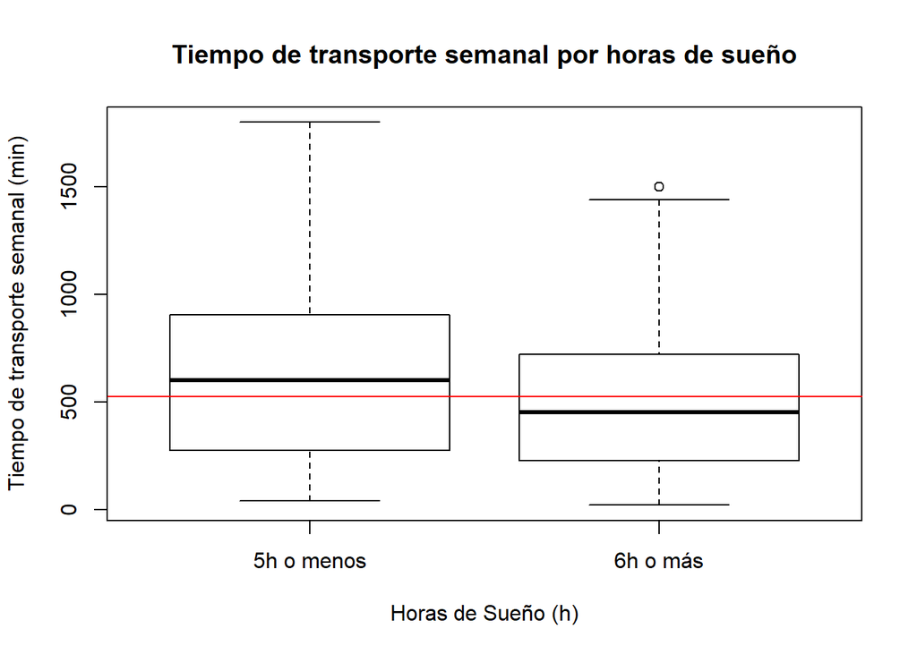

```r
boxplot(dmenos$Transporte_Semanal,dmas$Transporte_Semanal,names= c("5h o menos","6h o más"), main="Tiempo de transporte semanal por horas de sueño", ylab="Tiempo de transporte semanal (min)", xlab="Horas de Sueño (h)")
abline(h=mean(DF$Transporte_Semanal), col="red")
```

Dividiremos a los estudiantes en dos grupos diferentes de alumnos que duermen menos de 6 horas y alumnos que duermen de 6h a más.

Utilizaremos la mediana del tiempo de transporte semanal, **450 min**, de transporte de los estudiantes para verificar nuestra hipótesis.

**H0:** A menor tiempo de sueño del estudiante, mayor será el tiempo de transporte hacia la universidad.

**H1:** A menor tiempo de sueño del estudiante, menor será el tiempo de transporte hacia la universidad.

**Nivel de confianza:** 95%

**alpha**=0.05

```r
t.test(dmenos$Transporte_Semanal,mu=450,alternative = "less", conf.level = 0.95)
```

```
##
##  One Sample t-test
##
## data:  dmenos$Transporte_Semanal
## t = 2.1532, df = 42, p-value = 0.9815
## alternative hypothesis: true mean is less than 450
## 95 percent confidence interval:
##      -Inf 694.3868
## sample estimates:
## mean of x
##  587.2093
```

**ANÁLISIS:** Como el p-value es mayor a nuestro alpha, **(0.9815>0.05)**, no es posible descartar satisfactoriamente la hipótesis nula declarándola estadísticamente insignificante. Se filtraron los resultados en dos rangos de tiempo de sueño **5h o menos** y **6h o más** y los resultados de la media y la mediana apoyaban nuestra hipótesis nula demostrando que los alumnos que dormían 6h o más tenían un menor tiempo de transporte que los estudiantes que dormían 5h o menos.

**Comparando a los alumnos que duermen menos que la mediana vs los que duermen mas de la mediana**

```r
summary(dmenos$Transporte_Semanal)
```

```
##    Min. 1st Qu.  Median    Mean 3rd Qu.    Max.
##    40.0   275.0   600.0   587.2   905.0  1800.0
```

```r
summary(dmas$Transporte_Semanal)
```

```
##    Min. 1st Qu.  Median    Mean 3rd Qu.    Max.
##    20.0   225.0   450.0   504.1   720.0  1500.0
```

Dado lo anterior decidimos utilizar una prueba Chi-squared para verificar si las variables son dependientes o independientes y corroborar nuestra hipótesis inicial.

**Prueba chi-squared**

H0: Las variables son independientes H1: Las variables son dependientes

```r
chisq.test(table(DF$Transporte_Semanal, DF$Tiempo_Dormir))
```

```
##
##  Pearson's Chi-squared test
##
## data:  table(DF$Transporte_Semanal, DF$Tiempo_Dormir)
## X-squared = 324.51, df = 280, p-value = 0.03458
```

El p-value es menor al alpha (0.03458<0.05), entonces se rechaza la hipótesis nula.